# Practical Machine Learning-Final Project

MamidiSudheer

14 September 2017

The goal of project is to predict the manner in which people have done exercise.

#### Setting up Environment

```r
library(caret)
library(rpart)
library(rattle)
library(randomForest)
library(rpart.plot)
library(gbm)
library(ggplot2)
```

#### Importing Data

```r
training <- read.csv("pml-training.csv",stringsAsFactors = TRUE,header=T)
testing <- read.csv("pml-testing.csv",stringsAsFactors = TRUE,header=T)
```

```r
dim(training)
```

```
## [1] 19622   160
```

#### Data Cleaning

Calculating NA count in each column

```r
#Replace empty values as NA and computing  NA count in all columns
training[training == ""] <- NA
Col_NA <- colSums(is.na(training))

table(Col_NA)
```

```
## Col_NA
##     0 19216
##    60   100
```

As the proportion of NA’s is very high in some columns, we shall remove those columns

```r
#Only keep those columns where no NA is present
training1 <- training[,Col_NA==0]
testing1 <- testing[,Col_NA==0]

dim(training1)
```

```
## [1] 19622    60
```

```r
#Remove first 7 columns as they are not involved in readings
training_final <- training1[,-c(1:7)]
testing_final <- testing1[,-c(1:7)]
```

#### Splitting Data

```r
#Create a validation set
set.seed(1234)
inTrain  <- createDataPartition(training_final$classe, p=0.7, list=FALSE)
Train <- training_final[inTrain, ]
Test  <- training_final[-inTrain, ]

dim(Train)
```

```
## [1] 13737    53
```

#### Model- Decision Tree

Fitting a decision tree on Traindata.

model_rpart <- train(classe~., data = Train, method=“rpart”)

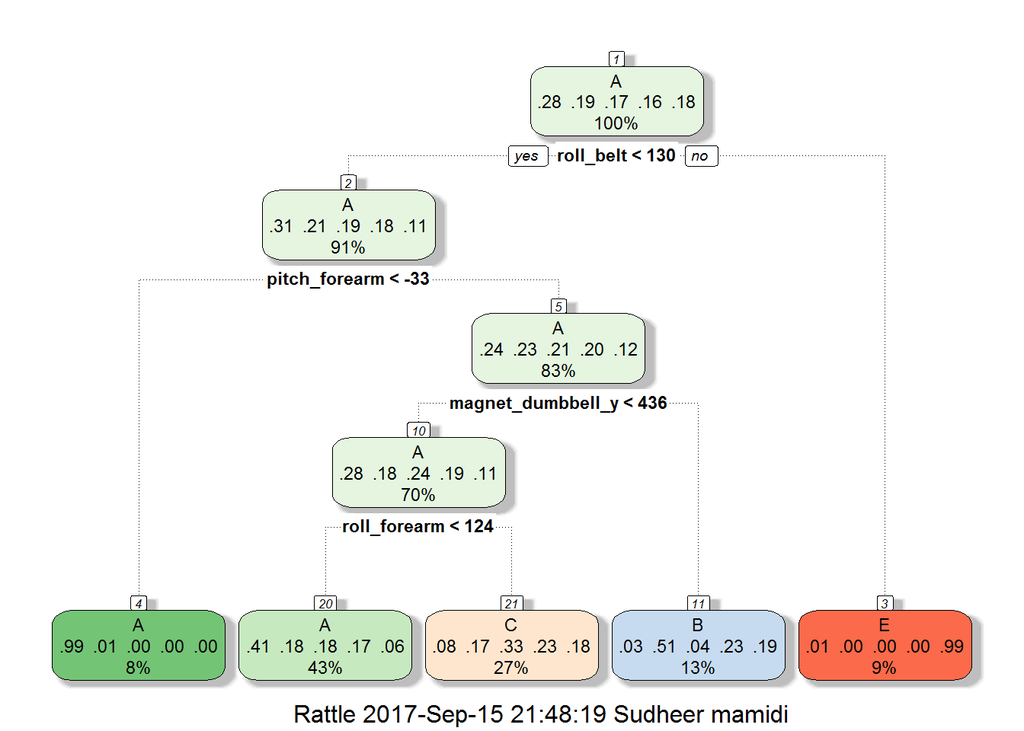

```r
fancyRpartPlot(model_rpart$finalModel)
```

Predicting using this model on validation data

```r
predict_decisiontree <- predict(model_rpart,Test)

cf_rpar <- confusionMatrix(predict_decisiontree,Test$classe)

#Accuracy
cf_rpar$overall[1]
```

```
##  Accuracy
## 0.4890399
```

```r
##set up the parallel processing

library(parallel)
h <-makeCluster(detectCores()-1)
```

#### RandomForest

Fitting a predictive modelusing Random Forest algorithm. Used 5-fold cross validation when applying the algorithm

```r
library(randomForest)
set.seed(1234)

#Using cross-validation as control
Control <- trainControl(method='cv', number = 5)
```

model_rf <- train(classe~., data = Train, method=“rf”,trControl=Control,allowParallel =TRUE)

Then, we shall estimate the performance of the model on the validation data set

```r
#Predicting on test set
predict_rf <- predict(model_rf,Test)

cf_rf <- confusionMatrix(predict_rf,Test$classe)

confusionMatrix(predict_rf,Test$classe)
```

```
## Confusion Matrix and Statistics
##
##           Reference
## Prediction    A    B    C    D    E
##          A 1674    8    0    0    0
##          B    0 1130    7    0    0
##          C    0    1 1018   10    1
##          D    0    0    1  954    1
##          E    0    0    0    0 1080
##
## Overall Statistics
##
##                Accuracy : 0.9951
##                  95% CI : (0.9929, 0.9967)
##     No Information Rate : 0.2845
##     P-Value [Acc > NIR] : < 2.2e-16
##
##                   Kappa : 0.9938
##  Mcnemar's Test P-Value : NA
##
## Statistics by Class:
##
##                      Class: A Class: B Class: C Class: D Class: E
## Sensitivity            1.0000   0.9921   0.9922   0.9896   0.9982
## Specificity            0.9981   0.9985   0.9975   0.9996   1.0000
## Pos Pred Value         0.9952   0.9938   0.9883   0.9979   1.0000
## Neg Pred Value         1.0000   0.9981   0.9984   0.9980   0.9996
## Prevalence             0.2845   0.1935   0.1743   0.1638   0.1839
## Detection Rate         0.2845   0.1920   0.1730   0.1621   0.1835
## Detection Prevalence   0.2858   0.1932   0.1750   0.1624   0.1835
## Balanced Accuracy      0.9991   0.9953   0.9949   0.9946   0.9991
```

```r
#Accuracy
cf_rf$overall[1]
```

```
##  Accuracy
## 0.9950722
```

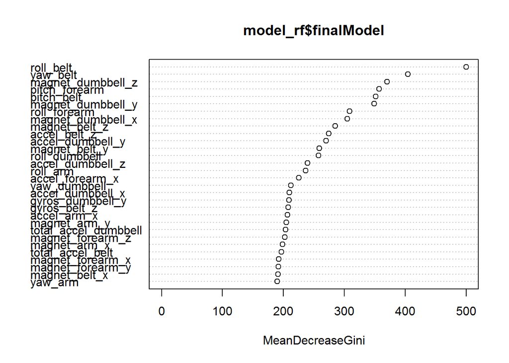

```r
#Variable Importance plot
varImpPlot(model_rf$finalModel)
```

So, accuracy is around 99.5% and estimated out of sample error around 0.5%

#### GBM

Now, we shall train the data using gradient boosting. Cross validation of 5 folds is done

```r
library(gbm)
Control <- trainControl(method='cv', number = 5)
set.seed(1256)
```

model_gbm <- train(classe~., data = Train, method = “gbm”, trControl = Control)

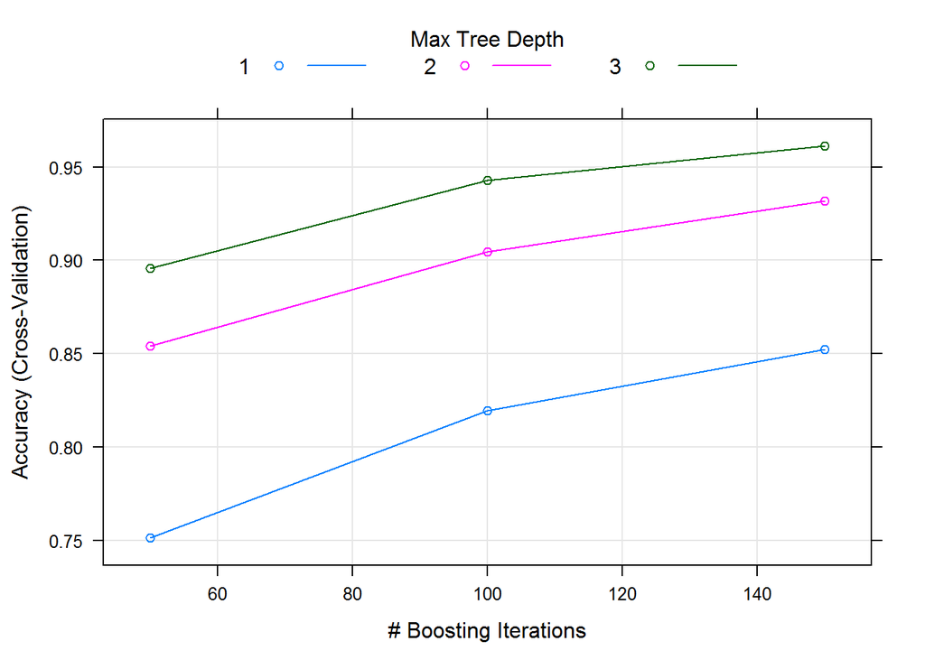

```r
plot(model_gbm)
```

Estimating using gbm on validation data

```r
predict_gbm <- predict(model_gbm,Test)

cf_gbm <- confusionMatrix(predict_gbm,Test$classe)


 cf_gbm$overall[1]
```

```
##  Accuracy
## 0.9638063
```

Accuracy is around 96.4% but less than RandomForest. So final prediction is done by RandomForest

#### Prediction on Test Set

```r
predict_final <- predict(model_rf,testing_final)
predict_final
```

```
##  [1] B A B A A E D B A A B C B A E E A B B B
## Levels: A B C D E
```

#### Appendix

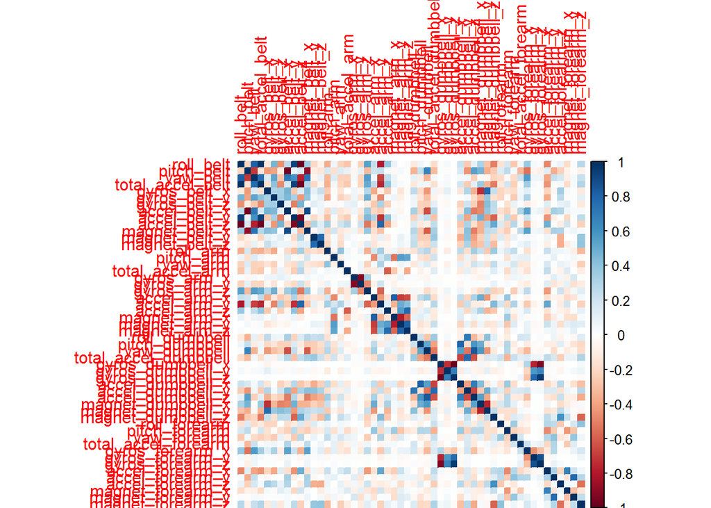

```r
library(corrplot)
corrplot(cor(Train[, -length(names(Train))]),method="color")
```

#### Data Source

https://d396qusza40orc.cloudfront.net/predmachlearn/pml-training.csv

https://d396qusza40orc.cloudfront.net/predmachlearn/pml-testing.csv